# CSHS Webinar - Introduction to Spatial Vector Data Analysis in R

2020-December-01

## Spatial analysis in R

- spatial raster data (**raster**, **velox**)
- geostatistical modelling and interpolation (**gstat**)
- remote sensing and image analysis (**RStoolbox**, **landsat**)
- links to external GIS packages (**RSAGA**, **RGRASS**)
- spatial vector data (**sp**, **sf**)

## Simple features and their implementation in R

## Characteristics of **sf** objects

- Simple Features are implemented within R as data frames.
- Each row represents a feature.
- Attributes are stored in columns.
- Geometries are stored as a list-column; each element corresponds to a specific feature.

## Simple feature geometry types

In addition to the POINT type, common geometry types include the following:

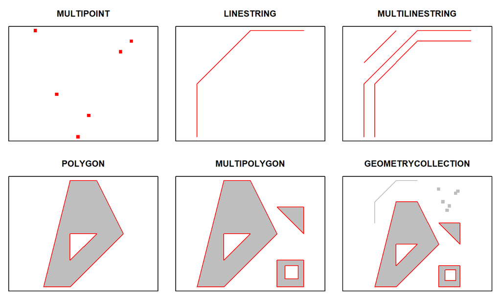

## Example - climate normals for stations near Vancouver

```r
# read data, convert longitude to negative
cn <- read.csv(here::here("data", "gvrdpt.csv")) %>%
  mutate(LONG = -LONG)
class(cn)
```

```
## [1] "data.frame"
```

```r
head(cn)
```

```
##   StationName ELEV PANN TANN SFANN      LAT      LONG
## 1     PtKells    9 1536  8.9    58 49.15000 -122.7000
## 2     NVanRed  229 2292   NA    87 49.36667 -123.0833
## 3     NVan2nd    4 1826   NA    45 49.30000 -123.0167
## 4    NVanHoly  183 1943   NA    72 49.35000 -123.0833
## 5    NVanLynn  191 2696   NA   118 49.36667 -123.0333
## 6     NVanClo   79 1860 10.0    88 49.31667 -123.0500
```

### Make a **sf** object

```r
# create sf object
cn_sf <- st_as_sf(cn, coords = c("LONG", "LAT"))
class(cn_sf)
```

```
## [1] "sf"         "data.frame"
```

### A quick look at the **sf** object

```r
head(cn_sf)
```

```
## Simple feature collection with 6 features and 5 fields
## geometry type:  POINT
## dimension:      XY
## bbox:           xmin: -123.0833 ymin: 49.15 xmax: -122.7 ymax: 49.36667
## CRS:            NA
##   StationName ELEV PANN TANN SFANN                   geometry
## 1     PtKells    9 1536  8.9    58       POINT (-122.7 49.15)
## 2     NVanRed  229 2292   NA    87 POINT (-123.0833 49.36667)
## 3     NVan2nd    4 1826   NA    45     POINT (-123.0167 49.3)
## 4    NVanHoly  183 1943   NA    72    POINT (-123.0833 49.35)
## 5    NVanLynn  191 2696   NA   118 POINT (-123.0333 49.36667)
## 6     NVanClo   79 1860 10.0    88   POINT (-123.05 49.31667)
```

### Set the coordinate reference system

```r
# use EPSG code for longlat coordinates
st_crs(cn_sf) <- 4326
```

### Extract and display the coordinate reference system

```r
# Extract into an object for later use
cn_crs <- st_crs(cn_sf)

# Display the crs in both epsg and proj4string formats
cn_crs$epsg
```

```
## [1] 4326
```

```r
cn_crs$proj4string
```

```
## [1] "+proj=longlat +datum=WGS84 +no_defs"
```

## Working with an **sf** object

## Selecting specific attributes (columns)

### By column number

```r
col_3 <- cn_sf[, 3]
class(col_3)
```

```
## [1] "sf"         "data.frame"
```

```r
head(col_3)
```

```
## Simple feature collection with 6 features and 1 field
## geometry type:  POINT
## dimension:      XY
## bbox:           xmin: -123.0833 ymin: 49.15 xmax: -122.7 ymax: 49.36667
## geographic CRS: WGS 84
##   PANN                   geometry
## 1 1536       POINT (-122.7 49.15)
## 2 2292 POINT (-123.0833 49.36667)
## 3 1826     POINT (-123.0167 49.3)
## 4 1943    POINT (-123.0833 49.35)
## 5 2696 POINT (-123.0333 49.36667)
## 6 1860   POINT (-123.05 49.31667)
```

### By column name with geometry

```r
pann <- cn_sf["PANN"]
class(pann)
```

```
## [1] "sf"         "data.frame"
```

### By column name without geometry

```r
pann <- cn_sf$PANN
class(pann)
```

```
## [1] "integer"
```

```r
head(pann)
```

```
## [1] 1536 2292 1826 1943 2696 1860
```

### Using `dplyr::select()`

```r
pann <- cn_sf %>%
  dplyr::select(PANN, TANN)
head(pann)
```

```
## Simple feature collection with 6 features and 2 fields
## geometry type:  POINT
## dimension:      XY
## bbox:           xmin: -123.0833 ymin: 49.15 xmax: -122.7 ymax: 49.36667
## geographic CRS: WGS 84
##   PANN TANN                   geometry
## 1 1536  8.9       POINT (-122.7 49.15)
## 2 2292   NA POINT (-123.0833 49.36667)
## 3 1826   NA     POINT (-123.0167 49.3)
## 4 1943   NA    POINT (-123.0833 49.35)
## 5 2696   NA POINT (-123.0333 49.36667)
## 6 1860 10.0   POINT (-123.05 49.31667)
```

## Extracting specific rows

### Using **dplyr** functions

```r
cn_wet <- cn_sf %>%
  dplyr::filter(PANN > median(PANN, na.rm = TRUE))
head(cn_wet)
```

```
## Simple feature collection with 6 features and 5 fields
## geometry type:  POINT
## dimension:      XY
## bbox:           xmin: -123.15 ymin: 49.3 xmax: -123.0167 ymax: 49.36667
## geographic CRS: WGS 84
##   StationName ELEV PANN TANN SFANN                   geometry
## 1     NVanRed  229 2292   NA    87 POINT (-123.0833 49.36667)
## 2     NVan2nd    4 1826   NA    45     POINT (-123.0167 49.3)
## 3    NVanHoly  183 1943   NA    72    POINT (-123.0833 49.35)
## 4    NVanLynn  191 2696   NA   118 POINT (-123.0333 49.36667)
## 5     NVanClo   79 1860   10    88   POINT (-123.05 49.31667)
## 6    WVanPalm  122 1919   NA    58   POINT (-123.15 49.33333)
```

### Using indices

```r
i <- which(cn_sf$PANN > median(cn_sf$PANN, na.rm = TRUE))
head(i)
```

```
## [1] 2 3 4 5 6 7
```

```r
cn_wet <- cn_sf[i, ]
head(cn_wet)
```

```
## Simple feature collection with 6 features and 5 fields
## geometry type:  POINT
## dimension:      XY
## bbox:           xmin: -123.15 ymin: 49.3 xmax: -123.0167 ymax: 49.36667
## geographic CRS: WGS 84
##   StationName ELEV PANN TANN SFANN                   geometry
## 2     NVanRed  229 2292   NA    87 POINT (-123.0833 49.36667)
## 3     NVan2nd    4 1826   NA    45     POINT (-123.0167 49.3)
## 4    NVanHoly  183 1943   NA    72    POINT (-123.0833 49.35)
## 5    NVanLynn  191 2696   NA   118 POINT (-123.0333 49.36667)
## 6     NVanClo   79 1860   10    88   POINT (-123.05 49.31667)
## 7    WVanPalm  122 1919   NA    58   POINT (-123.15 49.33333)
```

## Extracting geometries

```r
cn_geom <- st_geometry(cn_sf)
class(cn_geom)
```

```
## [1] "sfc_POINT" "sfc"
```

```r
head(cn_geom)
```

```
## Geometry set for 6 features
## geometry type:  POINT
## dimension:      XY
## bbox:           xmin: -123.0833 ymin: 49.15 xmax: -122.7 ymax: 49.36667
## geographic CRS: WGS 84
## First 5 geometries:
```

```
## POINT (-122.7 49.15)
```

```
## POINT (-123.0833 49.36667)
```

```
## POINT (-123.0167 49.3)
```

```
## POINT (-123.0833 49.35)
```

```
## POINT (-123.0333 49.36667)
```

## Removing geometries

For some operations, it is important to remove the geometries to improve processing speed.

```r
cn_nogeom <- st_set_geometry(cn_sf, NULL)
head(cn_nogeom)
```

```
##   StationName ELEV PANN TANN SFANN
## 1     PtKells    9 1536  8.9    58
## 2     NVanRed  229 2292   NA    87
## 3     NVan2nd    4 1826   NA    45
## 4    NVanHoly  183 1943   NA    72
## 5    NVanLynn  191 2696   NA   118
## 6     NVanClo   79 1860 10.0    88
```

## Extracting coordinates

The function `st_coordinates()` extracts the coordinates into a matrix, the structure of which depends on the geometry type. For POINT data, it is two-column matrix.

```r
cn_xy <- st_coordinates(cn_sf)
head(cn_xy)
```

```
##           X        Y
## 1 -122.7000 49.15000
## 2 -123.0833 49.36667
## 3 -123.0167 49.30000
## 4 -123.0833 49.35000
## 5 -123.0333 49.36667
## 6 -123.0500 49.31667
```

## Transforming the CRS

```r
# EPSG code for UTM zone 10
utm_crs <- 26910
cn_utm <- st_transform(cn_sf, crs = utm_crs)
head(cn_utm)
```

```
## Simple feature collection with 6 features and 5 fields
## geometry type:  POINT
## dimension:      XY
## bbox:           xmin: 493947.6 ymin: 5444174 xmax: 521876.8 ymax: 5468221
## projected CRS:  NAD83 / UTM zone 10N
##   StationName ELEV PANN TANN SFANN                 geometry
## 1     PtKells    9 1536  8.9    58 POINT (521876.8 5444174)
## 2     NVanRed  229 2292   NA    87 POINT (493949.7 5468221)
## 3     NVan2nd    4 1826   NA    45 POINT (498788.3 5460806)
## 4    NVanHoly  183 1943   NA    72 POINT (493947.6 5466368)
## 5    NVanLynn  191 2696   NA   118 POINT (497579.9 5468218)
## 6     NVanClo   79 1860 10.0    88 POINT (496366.1 5462660)
```

## Plotting **sf** objects

## Using the `plot()` method

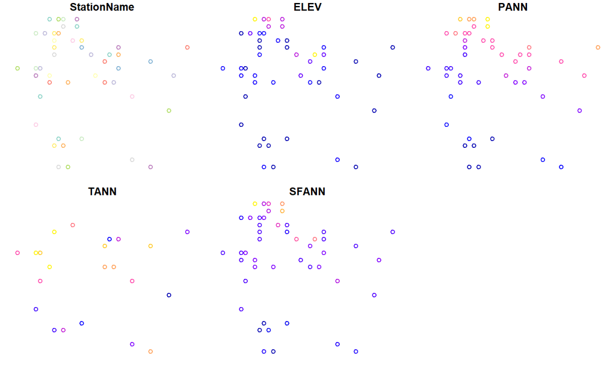

```r
plot(cn_sf)
```

## Using the `plot()` method – only the geometry

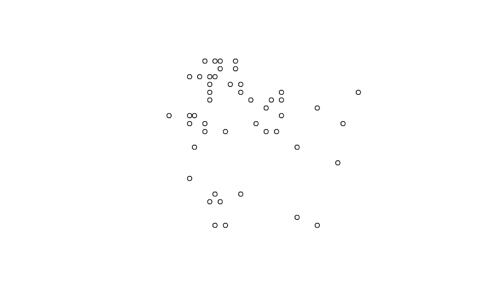

```r
plot(st_geometry(cn_sf))
```

## Using the `plot()` method – only the geometry and with some options

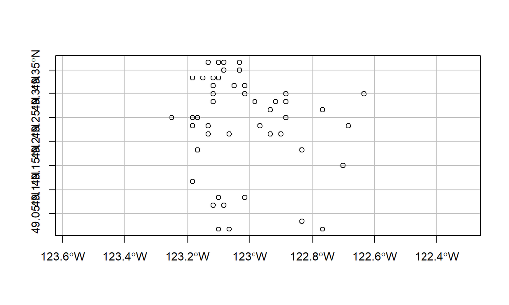

```r
plot(st_geometry(cn_sf), axes = TRUE, graticule = TRUE)
```

## `ggplot()` with no options

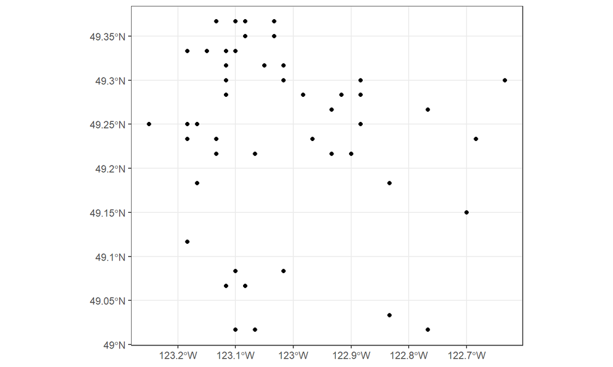

```r
ggplot() +
  geom_sf(data = cn_sf)
```

## `ggplot()` with `coord_sf()`

In the following example, the data are in longlat coordinates, and `ggplot()` performs the transformation to UTM prior to plotting.

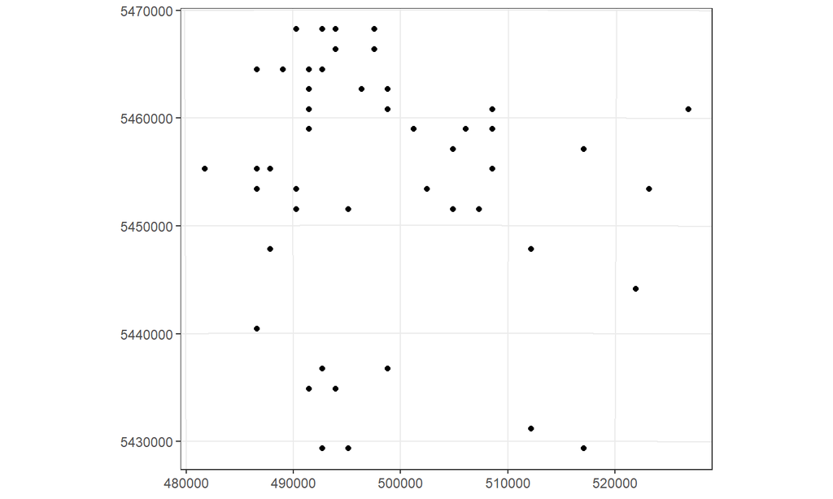

```r
ggplot() +
  geom_sf(data = cn_sf) +
  coord_sf(datum = utm_crs)
```

## `ggplot()` for projected data

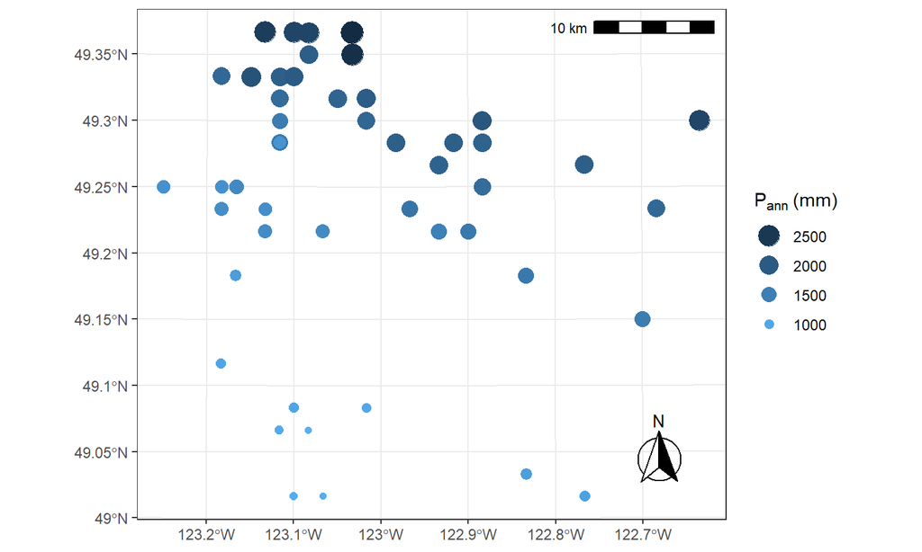

```r
ggplot() +
  geom_sf(data = cn_utm,
          aes(colour = PANN, size = PANN),
          show.legend = "point") +
  guides(colour = guide_legend(reverse = TRUE),
         size = guide_legend(reverse = TRUE)) +
  labs(colour = expression(P[ann] ~ "(mm)"),
       size = expression(P[ann] ~ "(mm)")) +
  scale_color_gradient(low = "#56B1F7", high = "#132B43") +
  annotation_scale(location = "tr", width_hint = 0.25) +
  annotation_north_arrow(location = "br", which_north = "true",
        pad_x = unit(0.25, "in"),
        pad_y = unit(0.25, "in"),
        style = north_arrow_fancy_orienteering)
```

## `ggplot()` for projected data - with `coord_sf()`

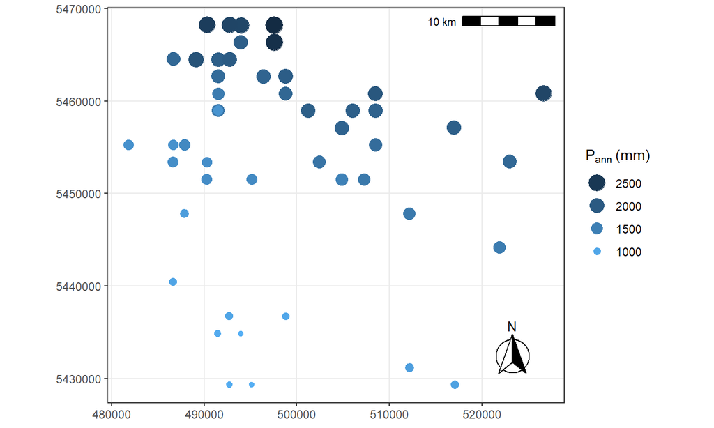

```r
ggplot() +
  geom_sf(data = cn_utm,
          aes(colour = PANN, size = PANN),
          show.legend = "point") +
  coord_sf(datum = utm_crs) +
  guides(colour = guide_legend(reverse = TRUE),
         size = guide_legend(reverse = TRUE)) +
  labs(colour = expression(P[ann] ~ "(mm)"),
       size = expression(P[ann] ~ "(mm)")) +
  scale_color_gradient(low = "#56B1F7", high = "#132B43") +
  annotation_scale(location = "tr", width_hint = 0.25) +
  annotation_north_arrow(location = "br", which_north = "true",
        pad_x = unit(0.25, "in"),
        pad_y = unit(0.25, "in"),
        style = north_arrow_fancy_orienteering)
```

## Reading and writing spatial data

## Available drivers

A broad range of drivers is available for reading and writing spatial vector data. Some examples include

- `ESRI shapefile`
- `KML`
- `netCDF`
- `GeoJSON`

You can view a full list via the following code:

```r
## Not run:
st_drivers()
```

## `st_read()`

The main argument in the `st_read()` function is `dsn`, the data source name.

Depending on the driver, `dsn` may be a file name, a folder, or an open database connection.

The function will automatically find the ‘geometry’ type columns for drivers that support it.

## `st_write()`

The main arguments are

- `obj` - object of class `sf` or `sfc`
- `dsn` - name of file/folder/database connection to write data to
- `layer` - name of layer to write
- `driver` - name of driver to be used (e.g., `KML`, `GeoJSON`); if missing, the driver type will be guessed from `dsn`

## Spatial vector data accessible via R packages

Examples include:

- **rnaturalearth** - provides access to Natural Earth (http://www.naturalearthdata.com/) public domain vector and raster map data
- **osmdata** - provides access to *Open Street Maps* crowd-sourced geographic data; vector layers are accessible via package
- **ggmap** - provides access to base maps from Google Earth, Google Maps, Stamen Maps and OpenStreetMap
- **bcmaps** - provides access to a range of vector data sets relevant to British Columbia

## **sf** for GIS operations

## Methods available

**sf** provides methods for a broad range of aspatial, spatial and geometric operations that would typically be performed in stand-alone GIS package. Some examples include:

- `st_crop()`
- `st_buffer()`
- `st_intersection()`
- `st_distance()`
- `st_area()`

You can view a full list via:

```r
## Not run:
methods(class = "sf")
```

## CSHShydRology page

https://cshs.cwra.org/hydrology/